#### Introduction :

First I choose the prosper loan data , becuase it is useful for the economy envirmont , and I like to analysis :),, the first step is load the file after that chech the summary of the data :

```
##                    ListingKey     ListingNumber
##  17A93590655669644DB4C06:     6   Min.   :      4
##  349D3587495831350F0F648:     4   1st Qu.: 400919
##  47C1359638497431975670B:     4   Median : 600554
##  8474358854651984137201C:     4   Mean   : 627886
##  DE8535960513435199406CE:     4   3rd Qu.: 892634
##  04C13599434217079754AEE:     3   Max.   :1255725
##  (Other)                :113912
##                     ListingCreationDate  CreditGrade         Term
##  2013-10-02 17:20:16.550000000:     6          :84984   Min.   :12.00
##  2013-08-28 20:31:41.107000000:     4   C      : 5649   1st Qu.:36.00
##  2013-09-08 09:27:44.853000000:     4   D      : 5153   Median :36.00
##  2013-12-06 05:43:13.830000000:     4   B      : 4389   Mean   :40.83
##  2013-12-06 11:44:58.283000000:     4   AA     : 3509   3rd Qu.:36.00
##  2013-08-21 07:25:22.360000000:     3   HR     : 3508   Max.   :60.00
##  (Other)                      :113912   (Other): 6745
##                  LoanStatus                  ClosedDate
##  Current              :56576                      :58848
##  Completed            :38074   2014-03-04 00:00:00:  105
##  Chargedoff           :11992   2014-02-19 00:00:00:  100
##  Defaulted            : 5018   2014-02-11 00:00:00:   92
##  Past Due (1-15 days) :  806   2012-10-30 00:00:00:   81
##  Past Due (31-60 days):  363   2013-02-26 00:00:00:   78
##  (Other)              : 1108   (Other)            :54633
##   BorrowerAPR       BorrowerRate     LenderYield
##  Min.   :0.00653   Min.   :0.0000   Min.   :-0.0100
##  1st Qu.:0.15629   1st Qu.:0.1340   1st Qu.: 0.1242
##  Median :0.20976   Median :0.1840   Median : 0.1730
##  Mean   :0.21883   Mean   :0.1928   Mean   : 0.1827
##  3rd Qu.:0.28381   3rd Qu.:0.2500   3rd Qu.: 0.2400
##  Max.   :0.51229   Max.   :0.4975   Max.   : 0.4925
##  NA's   :25
##  EstimatedEffectiveYield EstimatedLoss   EstimatedReturn
##  Min.   :-0.183          Min.   :0.005   Min.   :-0.183
##  1st Qu.: 0.116          1st Qu.:0.042   1st Qu.: 0.074
##  Median : 0.162          Median :0.072   Median : 0.092
##  Mean   : 0.169          Mean   :0.080   Mean   : 0.096
##  3rd Qu.: 0.224          3rd Qu.:0.112   3rd Qu.: 0.117
##  Max.   : 0.320          Max.   :0.366   Max.   : 0.284
##  NA's   :29084           NA's   :29084   NA's   :29084
```

[output cut: 193 more lines]

```
##  Min.   :    0.00                Min.   :0.7000   Min.   : 0.00000
##  1st Qu.:    0.00                1st Qu.:1.0000   1st Qu.: 0.00000
##  Median :    0.00                Median :1.0000   Median : 0.00000
##  Mean   :   25.14                Mean   :0.9986   Mean   : 0.04803
##  3rd Qu.:    0.00                3rd Qu.:1.0000   3rd Qu.: 0.00000
##  Max.   :21117.90                Max.   :1.0125   Max.   :39.00000
##
##  InvestmentFromFriendsCount InvestmentFromFriendsAmount   Investors
##  Min.   : 0.00000           Min.   :    0.00            Min.   :   1.00
##  1st Qu.: 0.00000           1st Qu.:    0.00            1st Qu.:   2.00
##  Median : 0.00000           Median :    0.00            Median :  44.00
##  Mean   : 0.02346           Mean   :   16.55            Mean   :  80.48
##  3rd Qu.: 0.00000           3rd Qu.:    0.00            3rd Qu.: 115.00
##  Max.   :33.00000           Max.   :25000.00            Max.   :1189.00
##
```

from the output of the summary we have alot of information like the mean of the term is 40.83 and of the borrwoer rate is about 0.1928 ..etc

```
##
##   FALSE    TRUE
## 8150378 1078519
```

in this code we want check how many missing value , in here we observe 1078519 missing value and in the below code we want to check the coloms have the missing value :

```
##                          ListingKey                       ListingNumber
##                                   0                                   0
##                 ListingCreationDate                         CreditGrade
##                                   0                                   0
##                                Term                          LoanStatus
##                                   0                                   0
##                          ClosedDate                         BorrowerAPR
##                                   0                                  25
##                        BorrowerRate                         LenderYield
##                                   0                                   0
##             EstimatedEffectiveYield                       EstimatedLoss
##                               29084                               29084
##                     EstimatedReturn             ProsperRating..numeric.
##                               29084                               29084
##               ProsperRating..Alpha.                        ProsperScore
##                                   0                               29084
##           ListingCategory..numeric.                       BorrowerState
##                                   0                                   0
##                          Occupation                    EmploymentStatus
##                                   0                                   0
##            EmploymentStatusDuration                 IsBorrowerHomeowner
##                                7625                                   0
##                    CurrentlyInGroup                            GroupKey
##                                   0                                   0
##                    DateCreditPulled               CreditScoreRangeLower
##                                   0                                 591
##               CreditScoreRangeUpper             FirstRecordedCreditLine
##                                 591                                   0
##                  CurrentCreditLines                     OpenCreditLines
##                                7604                                7604
##          TotalCreditLinespast7years               OpenRevolvingAccounts
##                                 697                                   0
##         OpenRevolvingMonthlyPayment                InquiriesLast6Months
##                                   0                                 697
##                      TotalInquiries                CurrentDelinquencies
##                                1159                                 697
##                    AmountDelinquent             DelinquenciesLast7Years
##                                7622                                 990
##            PublicRecordsLast10Years           PublicRecordsLast12Months
##                                 697                                7604
```

[output cut: 27 more lines]

```
##                                   0                                   0
##                 LP_CustomerPayments        LP_CustomerPrincipalPayments
##                                   0                                   0
##                  LP_InterestandFees                      LP_ServiceFees
##                                   0                                   0
##                   LP_CollectionFees               LP_GrossPrincipalLoss
##                                   0                                   0
##                 LP_NetPrincipalLoss     LP_NonPrincipalRecoverypayments
##                                   0                                   0
##                       PercentFunded                     Recommendations
##                                   0                                   0
##          InvestmentFromFriendsCount         InvestmentFromFriendsAmount
##                                   0                                   0
##                           Investors
##                                   0
```

Detail about the culomns:

```
## 'data.frame':    113937 obs. of  81 variables:
##  $ ListingKey                         : Factor w/ 113066 levels "00003546482094282EF90E5",..: 7180 7193 6647 6669 6686 6689 6699 6706 6687 6687 ...
##  $ ListingNumber                      : int  193129 1209647 81716 658116 909464 1074836 750899 768193 1023355 1023355 ...
##  $ ListingCreationDate                : Factor w/ 113064 levels "2005-11-09 20:44:28.847000000",..: 14184 111894 6429 64760 85967 100310 72556 74019 97834 97834 ...
##  $ CreditGrade                        : Factor w/ 9 levels "","A","AA","B",..: 5 1 8 1 1 1 1 1 1 1 ...
##  $ Term                               : int  36 36 36 36 36 60 36 36 36 36 ...
##  $ LoanStatus                         : Factor w/ 12 levels "Cancelled","Chargedoff",..: 3 4 3 4 4 4 4 4 4 4 ...
##  $ ClosedDate                         : Factor w/ 2803 levels "","2005-11-25 00:00:00",..: 1138 1 1263 1 1 1 1 1 1 1 ...
##  $ BorrowerAPR                        : num  0.165 0.12 0.283 0.125 0.246 ...
##  $ BorrowerRate                       : num  0.158 0.092 0.275 0.0974 0.2085 ...
##  $ LenderYield                        : num  0.138 0.082 0.24 0.0874 0.1985 ...
##  $ EstimatedEffectiveYield            : num  NA 0.0796 NA 0.0849 0.1832 ...
##  $ EstimatedLoss                      : num  NA 0.0249 NA 0.0249 0.0925 ...
##  $ EstimatedReturn                    : num  NA 0.0547 NA 0.06 0.0907 ...
##  $ ProsperRating..numeric.            : int  NA 6 NA 6 3 5 2 4 7 7 ...
```

[output cut: 67 more lines]

### One varible Analysis :

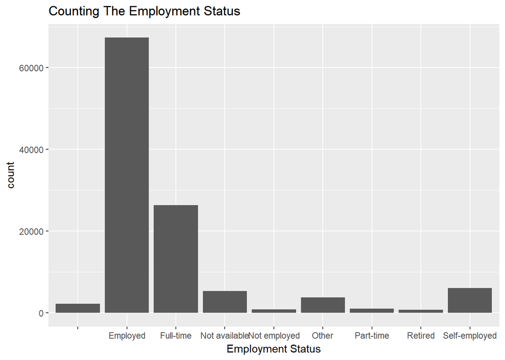

#### description 1:

In this plot we want to count the each Employment Status , and what we Observ is over 60000 is Employed and them the next full time . and less status is not employed and retired actually it is normal case.

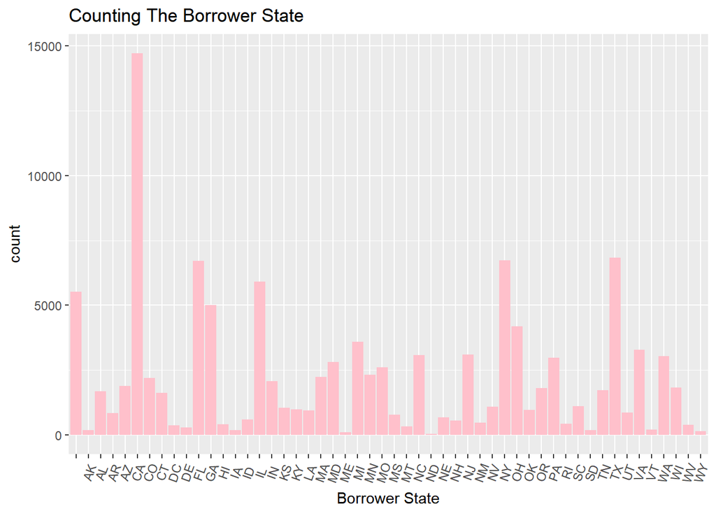

#### description 2:

In this case we want to count How many loan recorded in the bank , we Observe is CA the name is California State Take first rank in the Number of loan .California is the most populous state in the United States and the third most extensive by area. and the second rank is texas.

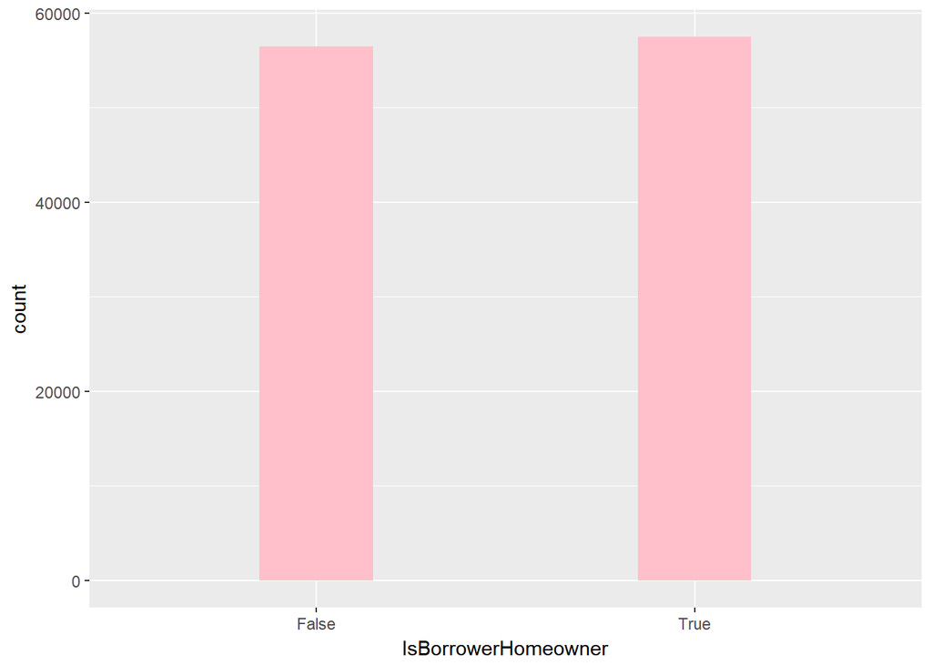

#### description 3:

here it is clear the most Borrowers have th house . so we think the loan take it not for build house , for another thing , for like cost of their son’s university .

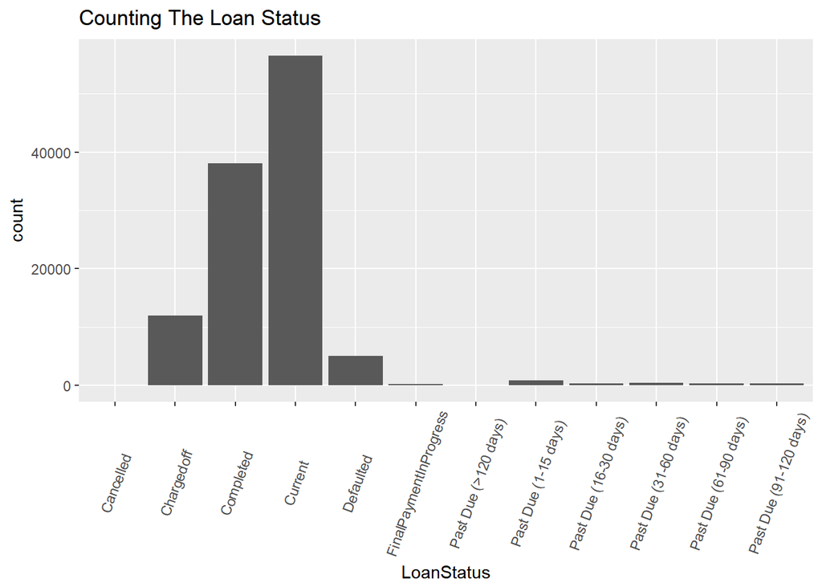

#### description 4:

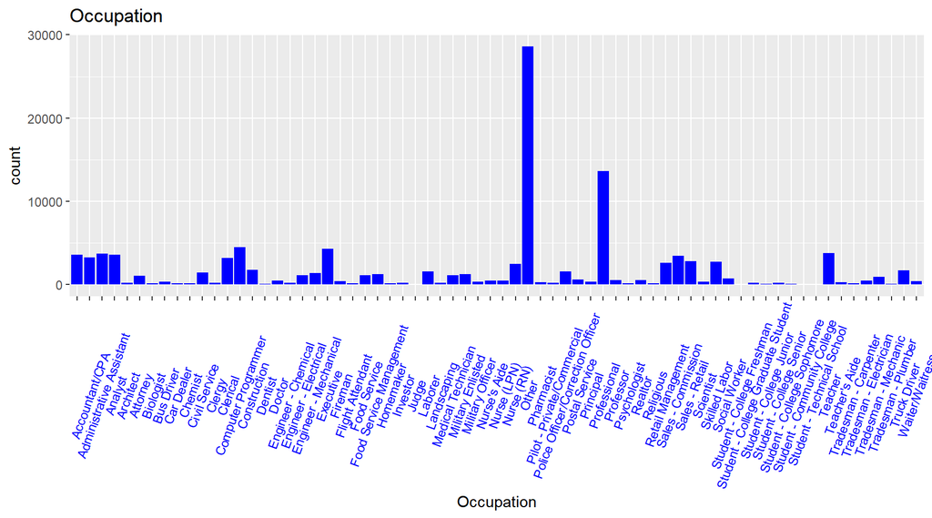

#### description 5:

already here we will ignore the “other” value , the occupation have the highet number take the loan as the professional .

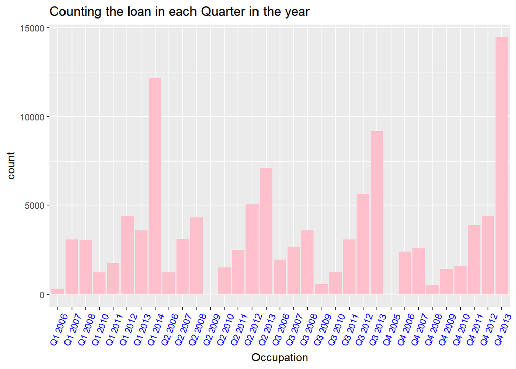

#### description 6:

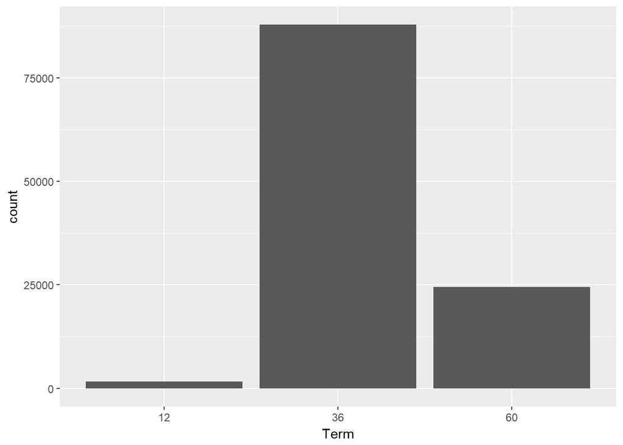

#### description 7:

the most of borrowes they spend about 2-4 years to return the loan .

in this section explore one varible we can say : * most of them hadthe house . * the professional jop is the most jop have loan. *the most yaer have request loan is 2013 .* most of the data the loan status is current. * The most of stats have high borrower is California.

### What is the structure of your dataset?

there is about 113937 Observation and 81 variable the data is about the loans between 2005-2014.

### What is the main feature of interest in your dataset?

the main varible im intrested is : -Trem -LoanStatus -Borrower rate -Borrower state -Occupation -Employment status -Is borrower has oner home -Avaiable Bank card credit -Income range -Stante monthly income -Loan orginal amount - Monthly loan Payment

### What other features in the dataset do you think will help support your the other feature will help me is when add new colomn call reasontoborrow .

### Two variable analysis :

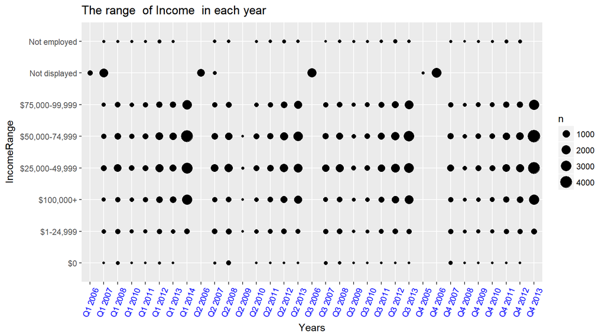

#### description 1:

now it is the best part :) , we can know what is the year have the highes income range, we can observe the yaer have the higest is Q4 2013 the income range is about 25,000-75,000 .so that explain the past plot whay we have alot loan request in the Q$ 2013 :)

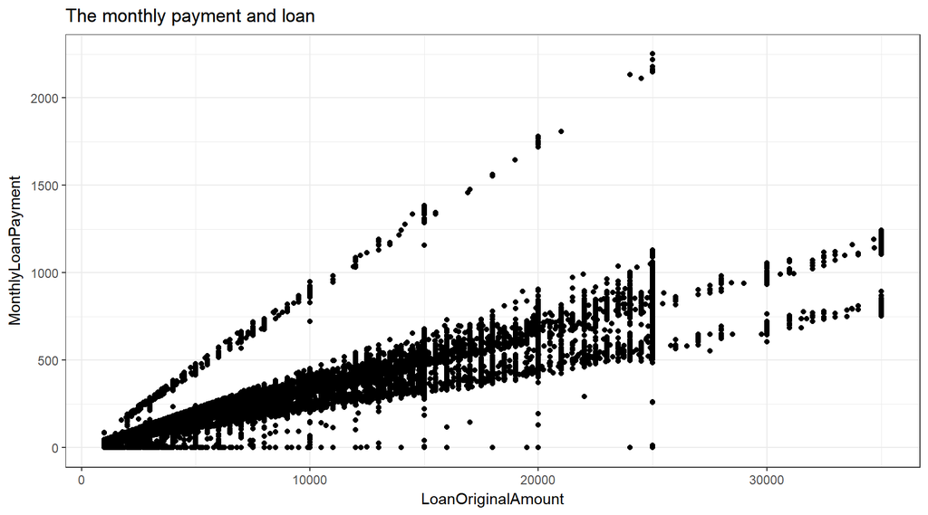

#### description 2:

that we see the loan original amount the max is about 35000 and the min is 1000 that mean thier salary low , and we have diffrent monthely payment according the loan original amount when increas the loan then will increase the monthely loan pay .in other side we observ most loan is about 0-15000 the plot have a dark section in this range .

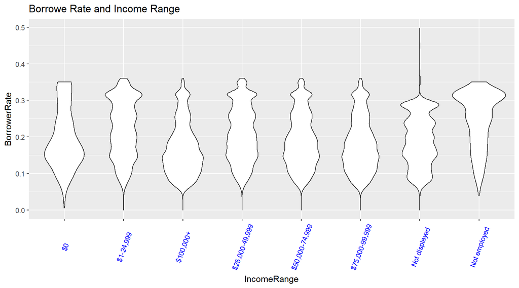

#### description 3:

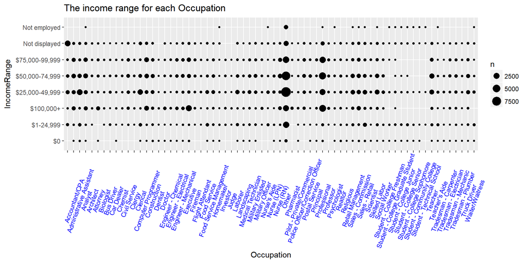

#### description 4:

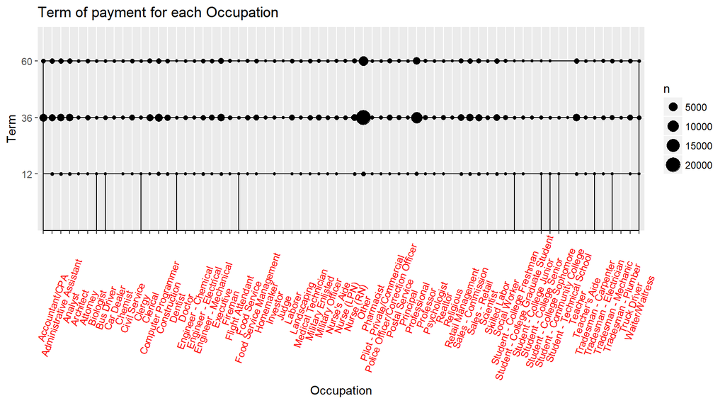

#### description 5:

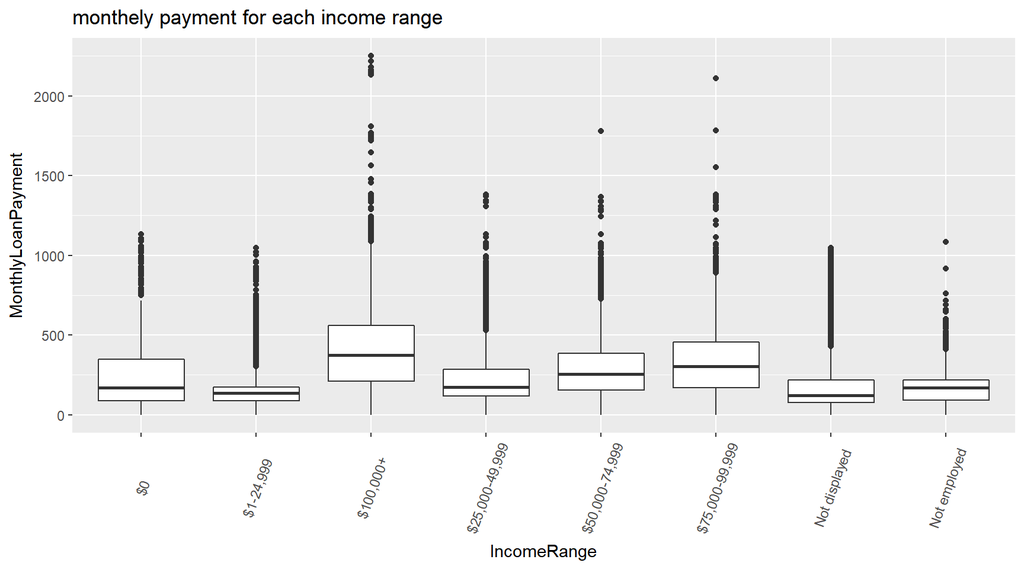

## Bivariate Analysis

### Did you observe any interesting relationships between the other features (not the main feature(s) of interest)?

No , I didn`t

### What was the strongest relationship you found?

the realationship between income range and value loan .

### exppolorate 3 varible :

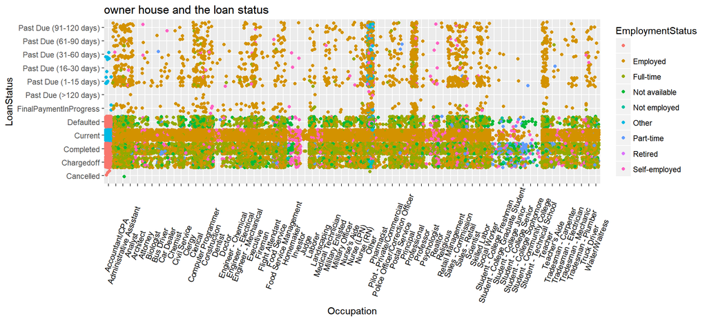

#### description 1:

Most of the occupation thier employment status is employed and the loan statust is current.

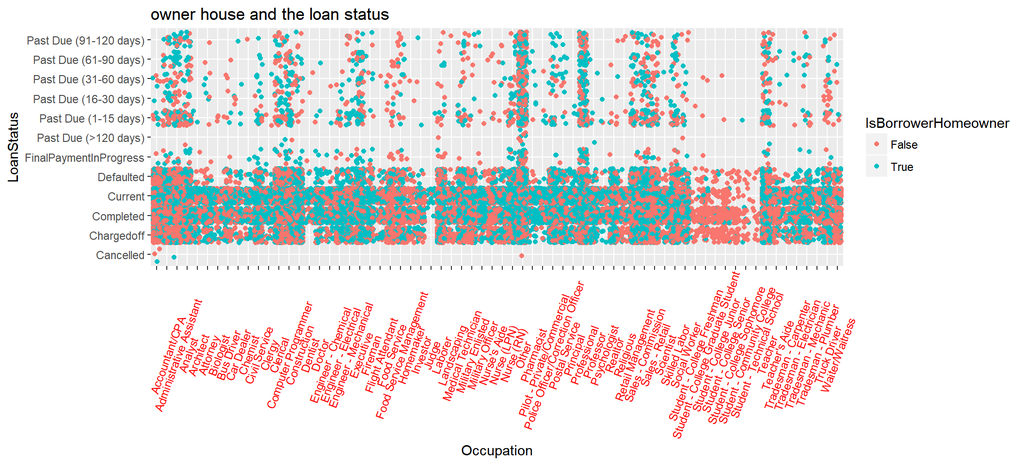

#### description 2:

The normal thing happened herem we observe the student they don`t have house they live with their family ,, we observe the Engineer and executive manager most of them have house.most of them have high salary , on other side for example we have food services , fireman and food service management and other jops most of them dont have house because of them low salary .

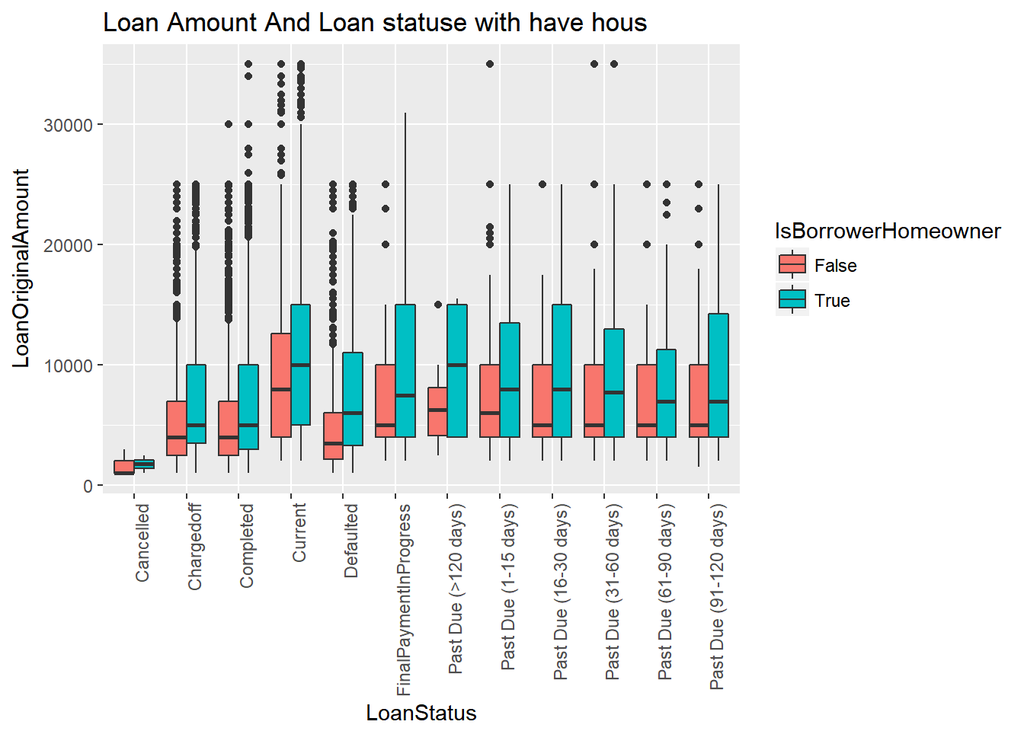

#### description 3:

here we will focuse in current status the median in the current status is about 10000 $.

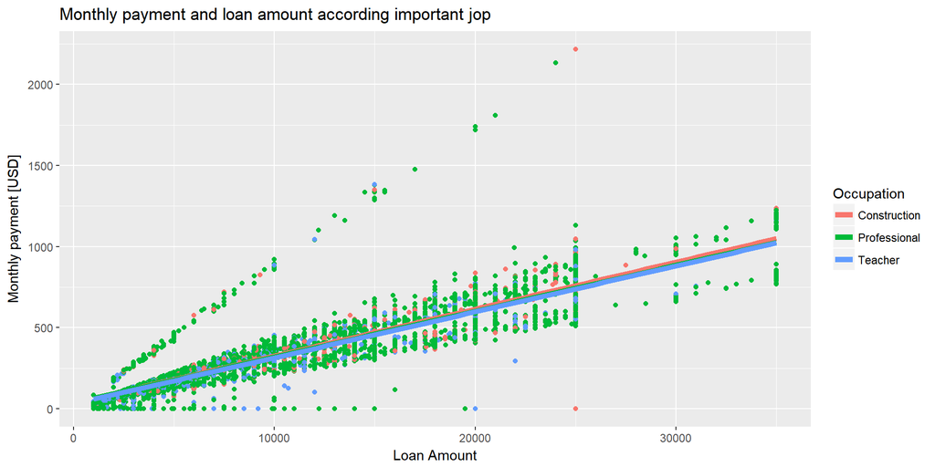

#### description 4:

# Multivariate Analysis

### Talk about some of the relationships you observed in this part of the investigation. Were there features that strengthened each other in terms of looking at your feature(s) of interest?

The most intrested in the professional jop is they have all the levels of loans and monthey payment.and the most intrested is most of the borrower have house.

### Were there any interesting or surprising interactions between features?

the peofessional jop have all levels of the loan original amount and monthely payment.

### Final Plots and Summary:

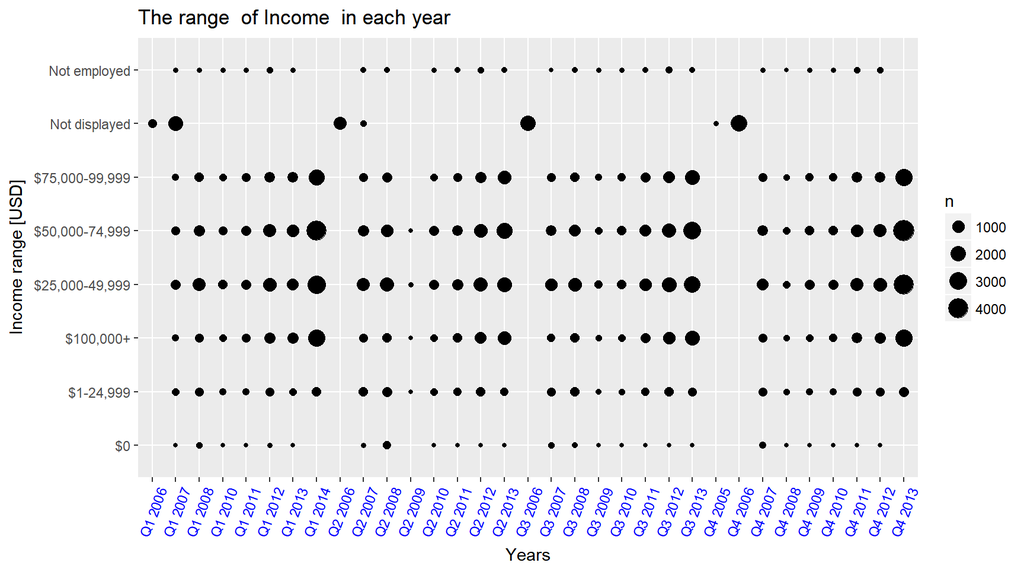

#### description 1:

here we observe the period is start from 2005 Q4 to Q1 2014 some Quarter is missing but according what we have the highest number of the loan is from Q4 2013 -Q1 2014 the 2013 and 2014 have the highes income range according the ecomomic information when have high salary then borrow more .

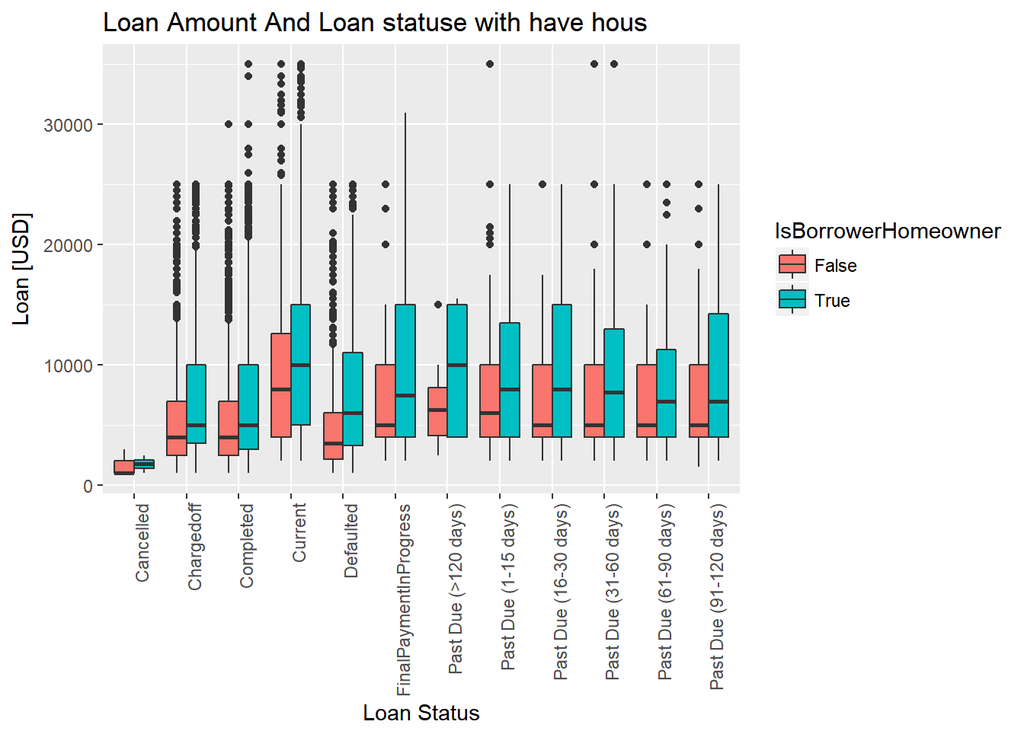

#### description 2:

here we observe the current status (important status ), the median in the current status is about 10000 $.

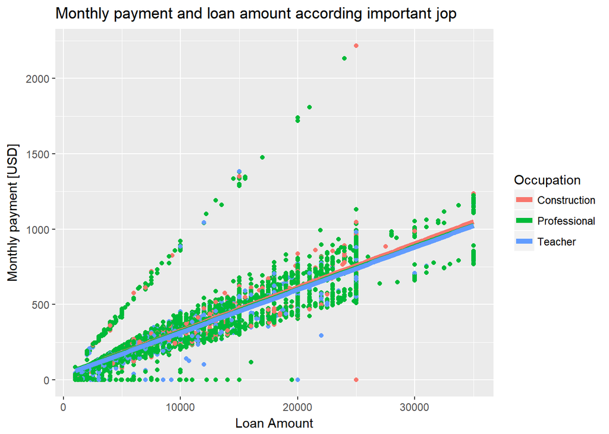

## Reflection:

The prosper loan Data have 113937 rows and 81 varible , have more detail about the requests of the loan from bank , the period is from 2005-2014 . first I started by understatnded all the varible and check what is the importent varaible , then I put many Qustion like * what is the min, max, mean for some variabl. *what is the highest salary and loan and Borrow rate And the jops have highest salary* according the isownerhome varible how many people have house . *what is the state have a highest Borrwer ? the difficult side in this project is programming by R and choose the dataset to explore. and  
the perfect time when the code running and when I see my work useful.

after Explore data : 1- is clear we have relation between incom range and loan original amount when we have high salary then increase the number of loans and the loans and increase the monthely payment. 2- the mean of trem is 40 months. 3- high number of loans in 2013 and high salary .

in the future we can enriched in future work collect more data to discover the future economy and to improve the performance of banks like .

finally it is great project I learned alot things :).

#### references:

https://www.analyticsvidhya.com/blog/2016/02/complete-tutorial-learn-data-science-scratch/#three